# STAT240 Final Project

2023-04-18

| Group Members |
| --- |
| STEVEN GE |
| Cathryn TOH |
| BENJAMIN BRANDEL |
| JINHAN YANG |

## Introduction

With water being a necessity to populations all across the globe, we decided to focus on access to safe drinking water along with the factors that affect it for our project. There is a general consensus that some countries tend to have higher access to safe drinking water with the years growing, but we wanted to research and make inferences to see if this was actually the case. Based off of this curiosity, our question of interest is: does higher GDP necessarily mean higher access to safe drinking water?

**Thesis statement:** The higher the GDP of a country, the higher its access to safe drinking water.

## Background

> The data set was collected by AQUASTAT. AQUASTAT is an organization that collects data about water usage from different countries. We selected 8 variables from the many indicators and data that AQUASTAT has information on: `GDP`, `Population density`, `Rural population`, `Rural population with access to safe dringking-water`, `Total population`, `Total population with access to safe drinking-water`, `Urban population`, and `Urban population with acccess to safe drinking-water`.

**GDP**: Gross Domestic Product (the monetary value of goods and services produced within a country’s borders in a given time period, in USD)

**Population density**: Population per km2

**Total population**: Total population of that country (per 1000 inhabitants)

**Rural population**: Total population of that country living in rural areas (per 1000 inhabitants)

**Urban population**: Total population of that country living in urban areas (per 1000 inhabitants)

**Total population with access to safe drinking-water**: % of total population with access to safe drinking-water

**Rural population with access to safe drinking-water**: % of rural population with access to safe drinking-water

**Urban population with access to safe drinking-water**: % of urban population with access to safe drinking-water

> This data was sourced from this URL: https://tableau.apps.fao.org/views/ReviewDashboard-v1/result_country?%3Aembed=y&%3AisGuestRedirectFromVizportal=y

> We want to find out if there exists any relationship between GDP and population access with safe drinking-water, so we chose GDP and population with access to safe drinking-water to determine if these pieces of data have any correlation.

> However, there are some interesting factors that affect our result. Initially, we intended to create a plot to compare the developing countries and developed countries to prove our hypothesis, but some developing countries had similar data to the developed countries in the data set. Take Bulgaria as an example. Bulgaria’s GDP is much lower than the United States, but Bulgaria has the same population percentage with access to safe drinking-water. By looking at the world map, we discovered that Bulgaria is nearby the Black Sea and the Mediterranean Sea, so we hypothesized that this could possibly be the reason why a developing and low-GDP country has the same extent of access to safe drinking-water as the United States.

## Analysis

> Below is GDP vs total population with access to safe drinking-water in all countries all over world

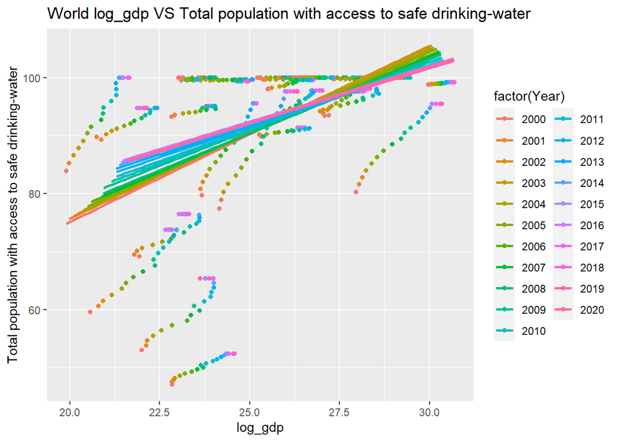

> Overall, for different years, the relationship between total population with access to safe drinking water and log_gdp is positive without considering whether the simple linear method is appropriate or not here.

We are interested in finding out if the slope of the regression line is positive or not.

### Hypothesis Test of all countries slope of regression lines in graph log_gdp vs Total population with access to safe drinking-water (2000-2020)

> Estimated model for regression line $Y_i = \beta_0 +\beta_1 * X_i$

> Hypothesis

$H_0 : \beta_1 = 0$ $H_a : \beta_1 > 0$

> Test statistic

```r
lm_world = lm(`Total population with access to safe drinking-water (JMP)`~log_gdp,data = question1)

summary(lm_world)
```

```
##
## Call:
## lm(formula = `Total population with access to safe drinking-water (JMP)` ~
##     log_gdp, data = question1)
##
## Residuals:
##     Min      1Q  Median      3Q     Max
## -38.696  -2.626   3.045   6.523  17.806
##
## Coefficients:
##             Estimate Std. Error t value Pr(>|t|)
## (Intercept)  30.0172     4.8576   6.179 1.16e-09 ***
## log_gdp       2.4417     0.1882  12.973  < 2e-16 ***
## ---
## Signif. codes:  0 '***' 0.001 '**' 0.01 '*' 0.05 '.' 0.1 ' ' 1
##
## Residual standard error: 11.27 on 628 degrees of freedom
## Multiple R-squared:  0.2113, Adjusted R-squared:  0.2101
## F-statistic: 168.3 on 1 and 628 DF,  p-value: < 2.2e-16
```

Test statistic for slope is 12.973

> Summary

The p_value is less than 5%. So this value is extremely significant and we can reject the null hypothesis that slope = 0. We do have enough evidence to prove that the slope is larger than 0. It seems that the slope of regression line here is positive. It seems that the higher GDP, the higher the access to safe drinking-water of total population.

> However. considering the influence of a variety of other factors such as continent, weather, and economy, it is hard to generate a plausible conclusion about the relation between GDP and total population with access to safe drinking-water of countries all over the world. It might be more reasonable to focus on a single country’s data.

> For the chunks below, we used the ggplot2 package to create several plots. We used the functions geom_point and geom_line to track the change of log_gdp and total population with access to safe drinking-water. We also utilized geom_smooth(method=“lm”) to create several regression lines to generate trends which is helpful in visualizing the relation between log_gdp and total population with access to safe drinking-water.

## North America

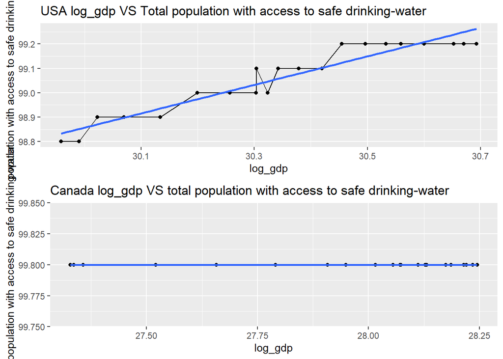

```
## # A tibble: 1 × 4
##   meanlog_gdp mean_jmp sd_jmp     r
##         <dbl>    <dbl>  <dbl> <dbl>
## 1        30.4     99.1  0.140 0.955
```

Based on the scatter plots of Canada and the United States of America, the relationship between GDP and total population with access to safe drinking-water can be categorized into two different types. The United States has a roughly positive relation between GDP and total population with access to safe drinking-water, but Canada has a horizontal line approximately which potentialy shows that GDP has no influence on Canada’s total population with access to safe drinking-water.

By inferring based on the correlation between total population with access to safe drinking-water and log_gdp of USA, we can safely conclude that for USA, as log_gdp get larger, the percentage of the total population with access to safe drinking-water tends to increase.

For the inference, we used the cor() function to get the correlation coefficient of these two variables.

## Hypothesis Test of USA’s slope of regression line in graph log_gdp vs Total population with access to safe drinking-water

> Estimated model for regression line $Y_i = \beta_0 +\beta_1 * X_i$

> Hypothesis

$H_0 : \beta_1 = 0$ $H_a : \beta_1 \neq 0$

> Test statistic

```
##
## Call:
## lm(formula = `Total population with access to safe drinking-water (JMP)` ~
##     log_gdp, data = usa_compare_data)
##
## Residuals:
##      Min       1Q   Median       3Q      Max
## -0.06194 -0.03542 -0.00210  0.02963  0.07711
##
## Coefficients:
##             Estimate Std. Error t value Pr(>|t|)
## (Intercept) 81.34206    1.26389   64.36  < 2e-16 ***
## log_gdp      0.58384    0.04164   14.02 1.79e-11 ***
## ---
## Signif. codes:  0 '***' 0.001 '**' 0.01 '*' 0.05 '.' 0.1 ' ' 1
##
## Residual standard error: 0.04251 on 19 degrees of freedom
## Multiple R-squared:  0.9119, Adjusted R-squared:  0.9072
## F-statistic: 196.6 on 1 and 19 DF,  p-value: 1.794e-11
```

Test statistic for slope is 14.02

> P_value

p_value = 2*(1-pt(14.03,df=19)) = 1.79e-11 approximately.

> Summary

The p_value is less than 1%. This value is very significant and we can reject the null hypothesis that slope = 0. We do have evidence to prove that the slope is not equal to 0. The simple linear method is appropriate here.

> We are interested in the slope of regression line between Total population with access to safe drinking-water and log_gdp and finding out if it is equal to 0 or not. The result shows that it is most likely that slope of regression line is not equal to 0.

## Asia

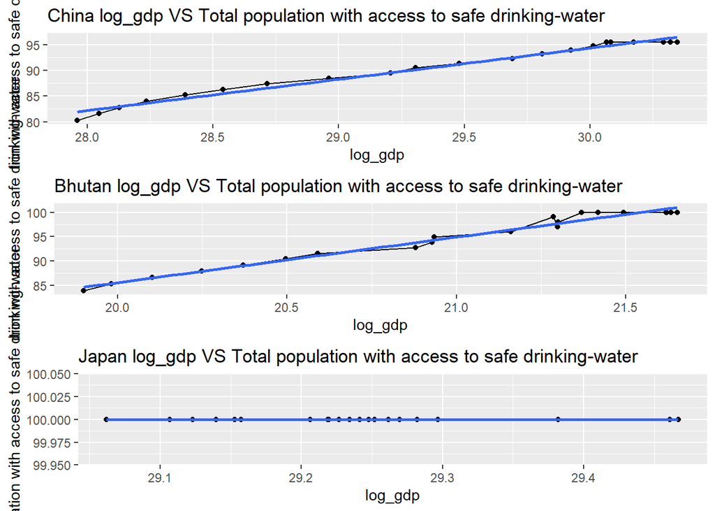

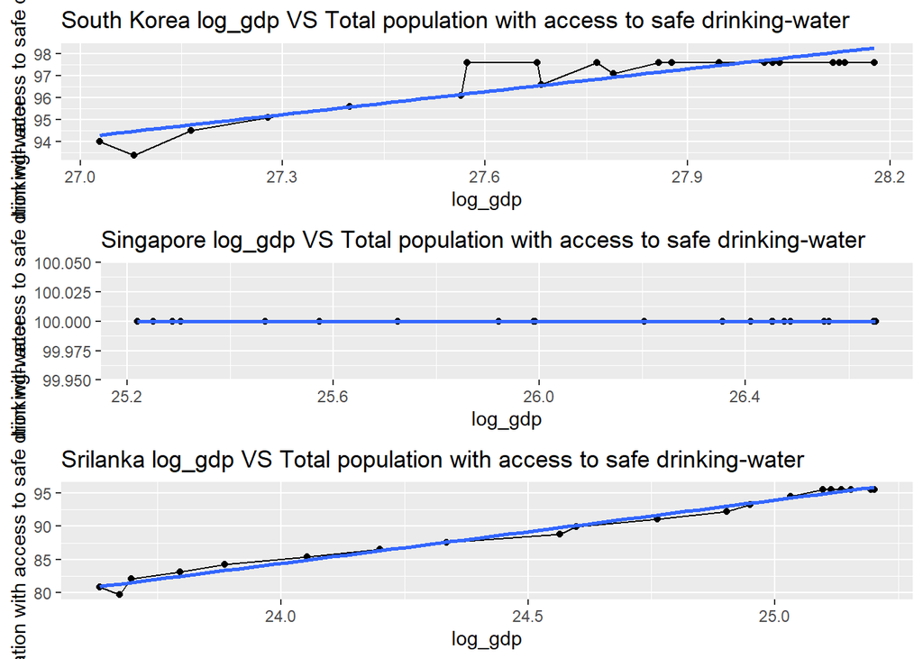

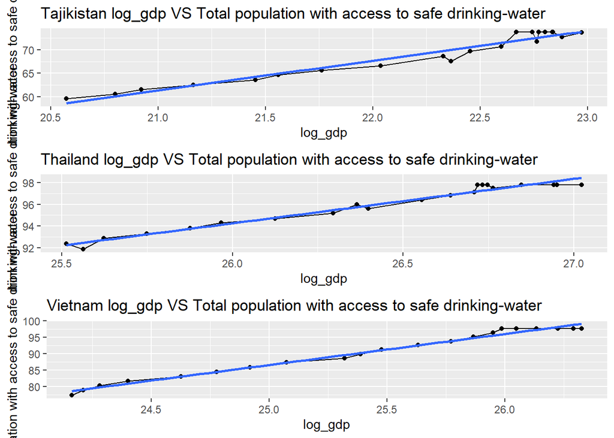

```
## # A tibble: 1 × 4
##   meanlog_gdp mean_jmp sd_jmp     r
##         <dbl>    <dbl>  <dbl> <dbl>
## 1        29.3     90.2   5.18 0.992
```

For the nine plots above, the relation between log_gdp and total population with access to safe drinking-water can also be categorized into two different groups. The first category is a horizontal line represented by Japan and Singapore. The second category is a positive line represented by China, Bhutan, South Korea, Sri Lanka, Tajikistan, Thailand, and Vietnam. For Japan and Singapore, the log_gdp seems to have no influence on their total population with access to safe drinking-water and for the other countries, the total population with access to safe drinking-water increases as log_gdp increases.

Specifically for China, its correlation coefficient (which was determined by the cor() function) shows a significant positive relation between log_gdp and total population with access to safe drinking-water. It seems that as log_gdp for China gets larger, the percentage of the total population with access to safe drinking-water tends to increase.

## Africa

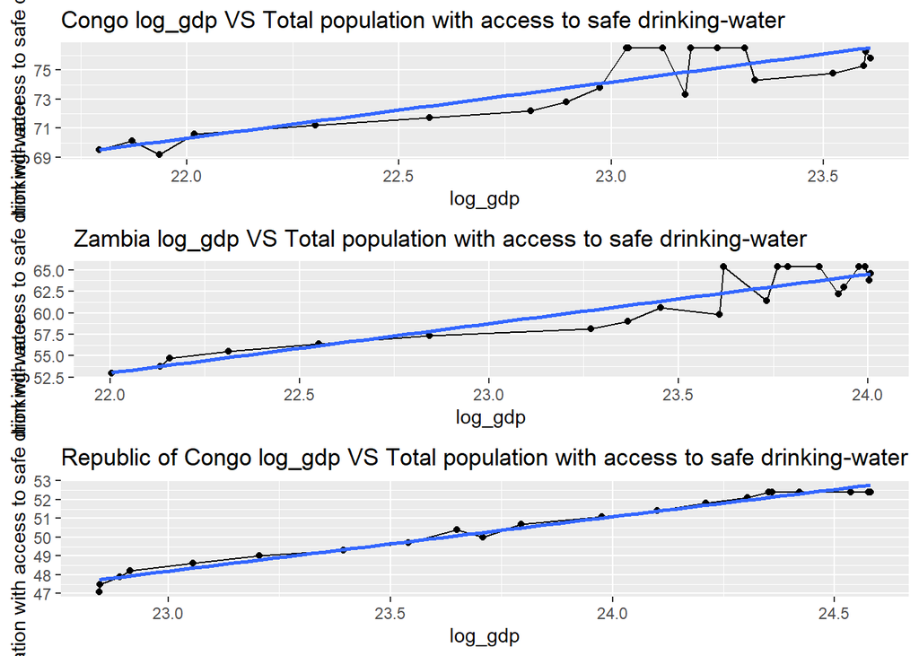

```
## # A tibble: 1 × 3
##   mean_jmp mean_log_gdp sd_jmp
##      <dbl>        <dbl>  <dbl>
## 1     67.3         23.1   7.50
```

From the three plots above, the relation between log_gdp and total population with access to safe drinking-water are all positive lines represented by Congo, Zambia, and Republic of Congo. Total population with access to safe drinking-water seems to increase when log_gdp increases.

## Oceania

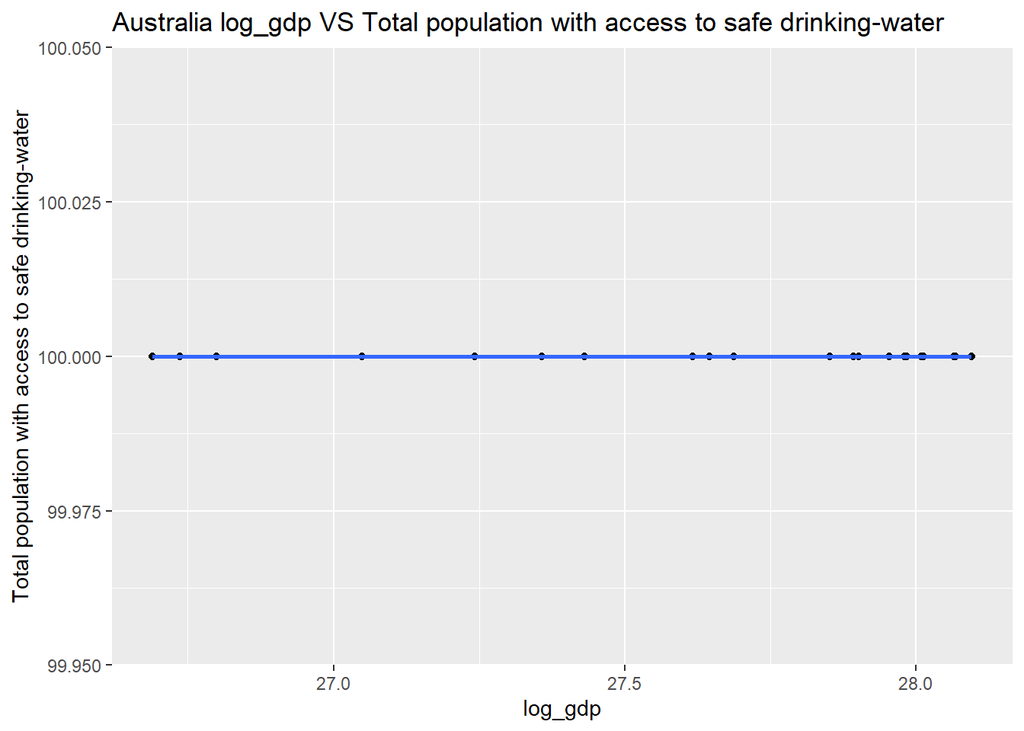

Oceania is dominated by the nation of Australia. From the plot above, it is a horizontal line and it is plausible because this continent is totally surrounded by ocean (and is also highly developed). So for this country, it seems that the log_gdp has no influence on access to safe water.

## Hypothesis Test of Australia’s slope of regression line in graph log_gdp vs Total population with access to safe drinking-water

> Estimated model for regression line $Y_i = \beta_0 +\beta_1 * X_i$

> Hypothesis

$H_0 : \beta_1 = 0$ $H_a : \beta_1 \neq 0$

> Test statistic

```
##
## Call:
## lm(formula = `Total population with access to safe drinking-water (JMP)` ~
##     log_gdp, data = australia_compare_data)
##
## Residuals:
##        Min         1Q     Median         3Q        Max
## -1.126e-14 -1.002e-14 -6.890e-15 -2.146e-15  1.202e-13
##
## Coefficients:
##              Estimate Std. Error   t value Pr(>|t|)
## (Intercept) 1.000e+02  3.777e-13 2.648e+14   <2e-16 ***
## log_gdp     1.070e-14  1.367e-14 7.820e-01    0.444
## ---
## Signif. codes:  0 '***' 0.001 '**' 0.01 '*' 0.05 '.' 0.1 ' ' 1
##
## Residual standard error: 2.87e-14 on 19 degrees of freedom
## Multiple R-squared:  0.4884, Adjusted R-squared:  0.4615
## F-statistic: 18.14 on 1 and 19 DF,  p-value: 0.000424
```

Test statistic for slope is 7.820e-01

> P_value

p_value = 2*(1-pt(7.820e-01 ,df=19)) = 0.444 approximately.

> Summary

> We are interested in the slope of Australia’s regression line because it looks horizontal and straight. The result proves the hypothesis we have that there is no apparent relationship between log_gdp and total population with access to safe drinking water.

## Europe

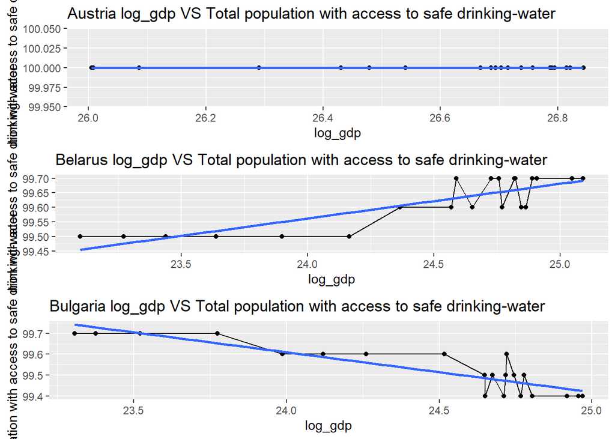

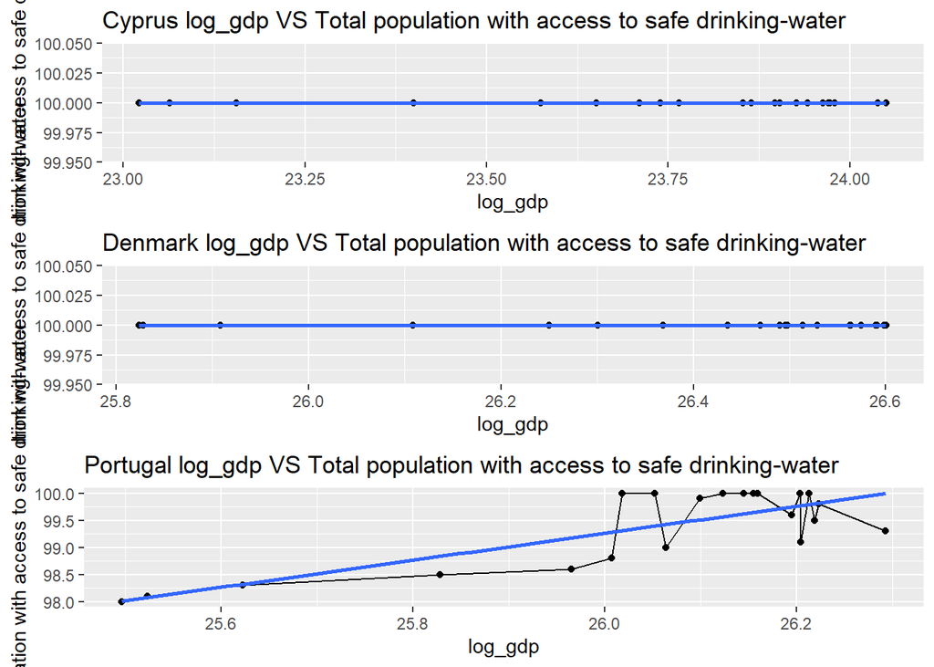

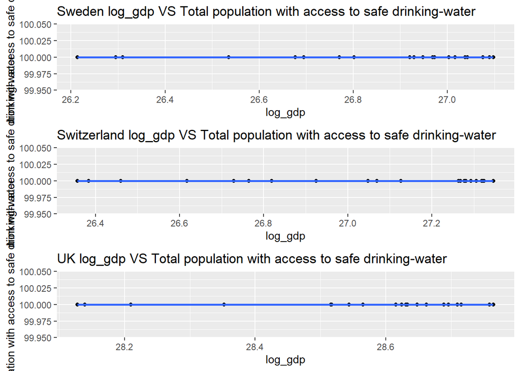

The nine plots above bring us a new type of trend: a negative trend represented by Bulgaria. For most of the other European countries chosen, the slopes of their regression lines are all approximately horizontal.

## South America

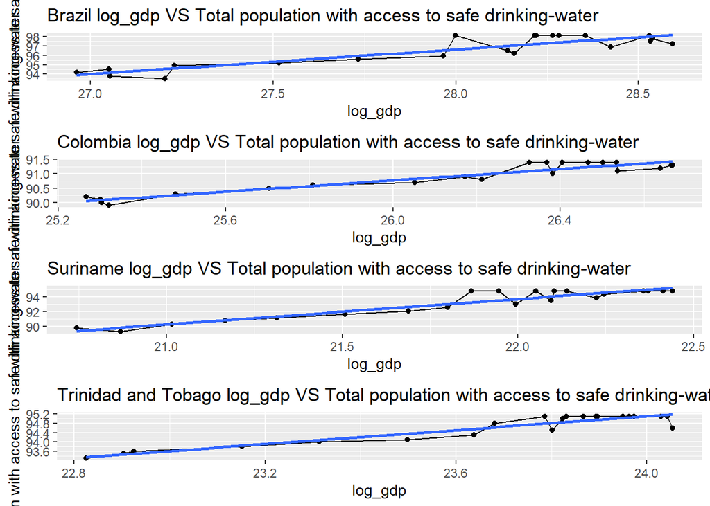

For the four plots above, the four countries chosen from South America shows a positive trend between total population with access to safe drinking-water and log_gdp. It seems that the log_gdp positively increases the total population with access to safe drinking-water when log_gdp increases for these countries.

# Main Conclusion

Only a few countries has negative trend between gdp and total population with access to safe drinking-water, Most of countries’ higher gdp will increase the total population with access to safe drinking-water accordingly except the countries that already achieved a steady 100% total population with access to safe drinking-water.

## Discussion

To restate our research statement from above, we are attempting to find out if there is any relationship between a countries GDP and the percent of the population that has access to clean drinking water.

Combining what we have found in our data and in the research, the overwhelming majority of countries, whose population percentage with access to safe drinking water is not already at or very close to 100%, has a positive relationship with GDP and population percentage with access to safe drinking water, and it is likely that this trend holds true for the rest of the world’s countries.

In the future, one thing that we could look at is more background factors in each of these countries that could also be influencing population percentage with access to safe drinking water apart from GDP, things such as country location, climate, population size, etc.

## Reference

[^1]

[^1]: https://tableau.apps.fao.org/#/views/AQUASTATDashboard/country_dashboard